# Sección A

# A.2 Carpetas de investigación

#NOTA IMPORTANTE. descargar el archivo “carpetas_inv.rds” y colocarlo en el mismo directorio de donde se ejecute este Notebook. # el link de descarga del archivo es el sig: ‘https://1drv.ms/u/s!As4zvXVPTtlMl3T9OTGL53HF6LVK?e=gt0otS’

# 1) ¿Qué pruebas identificarías para asegurar la calidad de estos datos?

Haría un resumen para cada una de las variables, tratando de identifcar si hay datos faltantes (NAs), si hay datos mixtos en una de las columnas (ej. el mes eté reportado como texto y/o número), que en las columnas donde haya un set limitado de opciones (ej. mes) no haya variantes de dichas opciones (ej. el mes de Marzo se haya escrito como ‘marzo’ u otra variante), que haya congruencia entre las alcaldías, colonias y calles.

# 2) ¿Cuántos delitos registrados hay en la tabla? ¿Qué rango de tiempo consideran los datos?

El número de delitos únicos en los datos es de 338 y el rango de fechas es:

```r
fechas.min.max
```

| fecha.min.hechos | fecha.max.hechos | fecha.min.inicio | fecha.max.inicio |
| --- | --- | --- | --- |
| 1954-05-04 19:54:00 | 2018-11-30 23:40:00 | 2001-01-20 19:00:35 | 2031-03-20 19:23:53 |

# 3) ¿Cómo se distribuye el número de delitos en la CDMX? ¿Cuáles son los 5 delitos más frecuentes?

Los 5 delitos más cometidos son : Violencia familiar, ROBO DE OBJETOS, ROBO A NEGOCIO SIN VIOLENCIA, FRAUDE y ROBO A TRANSEUNTE EN VIA PUBLICA CON VIOLENCIA. La distribución del número de delitos es la siguiente (hay 338 delitos diferentes y por lo tanto la visualización es dificil):

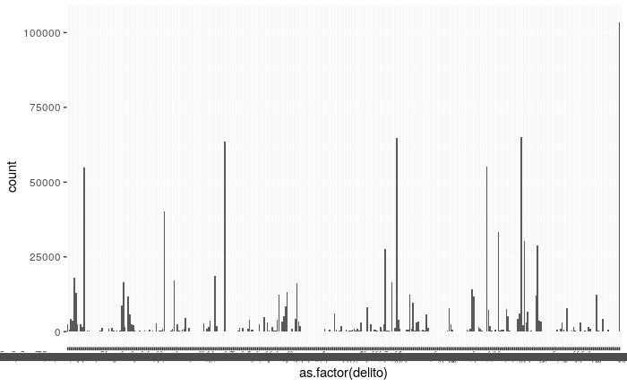

# 4) Identifica los delitos que van a la alza y a la baja en la CDMX en el último año

```r
alza.baja.delitos <- carpetas.inv[year(fecha_hechos) == 2018, semana := week(fecha_hechos)]
alza.baja.delitos <- alza.baja.delitos[, .(num.delitos = .N), .(delito, semana)]
alza.baja.delitos <- alza.baja.delitos[
  order(delito, semana),
  .(semana, pct.chg = (num.delitos - lag(num.delitos))/lag(num.delitos)),
  .(delito)
  ]

delitos.baja <- alza.baja.delitos[pct.chg < 0, pct.chg := as.integer(pct.chg*100)]
delitos.alza <- alza.baja.delitos[pct.chg > 0, pct.chg := as.integer(pct.chg*100)]

delitos.baja
delitos.alza
```

| delito | semana | pct.chg |
| --- | --- | --- |
| ABANDONO DE PERSONA | 1 | NA |
| ABANDONO DE PERSONA | 2 | -62 |
| ABANDONO DE PERSONA | 3 | 50 |
| ABANDONO DE PERSONA | 4 | 11 |
| ABANDONO DE PERSONA | 5 | 50 |
| ABANDONO DE PERSONA | 6 | -26 |
| ABANDONO DE PERSONA | 7 | 27 |
| ABANDONO DE PERSONA | 8 | -28 |
| ABANDONO DE PERSONA | 9 | 110 |
| ABANDONO DE PERSONA | 10 | -61 |

[output cut: 990 more lines]

# 5) ¿Cuál es la alcaldía que más delitos tiene y cuál es la que menos?. ¿Por qué crees que sea esto?

```r
delitos.alcaldia <- carpetas.inv[, .(num.delitos = .N), alcaldia_hechos]
delitos.alcaldia[order(num.delitos, decreasing = T),]
delitos.alcaldia[order(num.delitos, decreasing = F),]
```

[output not shown]

# 6) Dentro de cada alcaldía, cuáles son las tres colonias con más delitos

| alcaldia_hechos | colonia_hechos | num.delitos |
| --- | --- | --- |
|  |  | 2290 |
|  | NA | NA |
|  | NA | NA |
| ALVARO OBREGON | JARDINES DEL PEDREGAL | 3276 |
| ALVARO OBREGON | SAN ANGEL | 2630 |
| ALVARO OBREGON | ZEDEC SANTA FE | 2504 |
| AZCAPOTZALCO | EL ROSARIO | 3740 |
| AZCAPOTZALCO | INDUSTRIAL VALLEJO | 2466 |
| AZCAPOTZALCO | CENTRO DE AZCAPOTZALCO | 2280 |
| BENITO JUAREZ | DEL VALLE CENTRO | 16129 |

[output cut: 83 more lines]

# 7) ¿Existe alguna tendencia estacional en la ocurrencia de delitos (mes, semana, día de la semana, quincenas)?

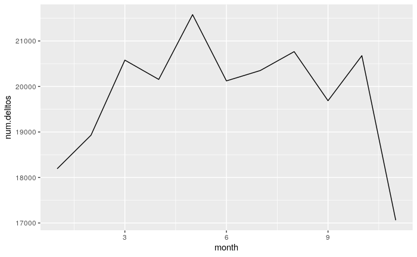

```r
delitos.2018 <- carpetas.inv[year(fecha_hechos) == 2018,  ]
delitos.2018.mes <- delitos.2018[, .(num.delitos = .N), month(fecha_hechos)]
delitos.2018.mes <- delitos.2018.mes[order(month),]

delitos.2018.week <- delitos.2018[, .(num.delitos = .N), week(fecha_hechos)]
delitos.2018.week <- delitos.2018.week[order(week),]

delitos.2018.day <- delitos.2018[, .(num.delitos = .N),  weekdays(fecha_hechos)]
#delitos.2018.day <- delitos.2018.day[order( weekdays),]

ggplot(delitos.2018.mes, aes(x=month, y = num.delitos)) + geom_line()
```

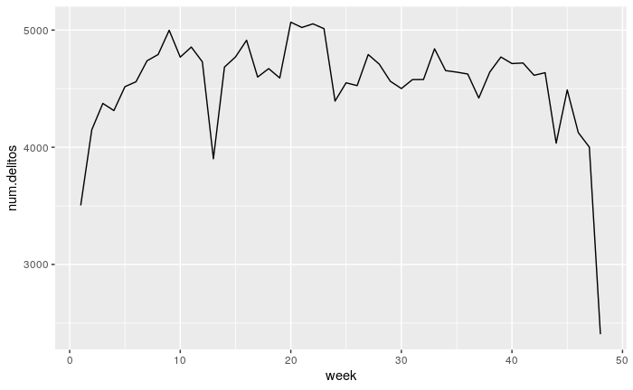

```r
ggplot(delitos.2018.week, aes(x=week, y = num.delitos)) + geom_line()
```

```r
delitos.2018.day
```

| weekdays | num.delitos |
| --- | --- |
| Saturday | 28648 |
| Friday | 34042 |
| Sunday | 25294 |
| Wednesday | 32913 |
| Thursday | 32303 |
| Tuesday | 32360 |
| Monday | 32540 |

# 8) ¿Cuales son los delitos que más caracterizan a cada alcaldía? Es decir, delitos que

suceden con mayor frecuencia en una alcaldía y con menor frecuencia en las demás.

```r
delitos.alcaldia.carac <- carpetas.inv[, .(num.delitos = .N), .(delito, alcaldia_hechos)]
delitos.alcaldia.carac[, .SD[1], alcaldia_hechos]
```

| alcaldia_hechos | delito | num.delitos |
| --- | --- | --- |
| IZTAPALAPA | VIOLENCIA FAMILIAR | 19078 |
| IZTACALCO | VIOLENCIA FAMILIAR | 6253 |
| TLAHUAC | ROBO A NEGOCIO CON VIOLENCIA | 522 |
| ALVARO OBREGON | ROBO A CASA HABITACION SIN VIOLENCIA | 1722 |
| CUAUHTEMOC | ROBO DE OBJETOS | 12665 |
| VENUSTIANO CARRANZA | TENTATIVA DE ROBO DE VEHICULO | 24 |
| BENITO JUAREZ | ROBO DE OBJETOS DEL INTERIOR DE UN VEHICULO | 3570 |
|  | ABUSO SEXUAL | 52 |
| GUSTAVO A MADERO | ROBO DE VEHICULO DE SERVICIO PARTICULAR SIN VIOLENCIA | 3770 |
| COYOACAN | VIOLENCIA FAMILIAR | 6720 |

[output cut: 519 more lines]

# 10) ¿Cómo diseñarías un indicador que midiera el nivel “inseguridad”? Diséñalo al nivel de desagregación que te parezca más adecuado (ej. manzana, calle, AGEB, etc.).

R: Haría un indicador que midiera el porcentaje de cambio del número de delitos dada una colonia, semana del año y núm. de habitantes (algo como (#de delitos en la semana del año)/(#habitantes en colonia) y mediría el cambio semana a semana de este indicador)

# 12) Toma los delitos clasificados como “Robo a pasajero a bordo de transporte público con y sin violencia”. ¿Cuáles son las ruta de transporte público donde más ocurren estos delitos?

R: La calle que registra más delitos del tipo “Robo a pasajero a bordo de transporte público con y sin violencia” es Calzada Ignacio Zaragoza

| calle_hechos | num.delitos |
| --- | --- |
| CALZADA IGNACIO ZARAGOZA | 214 |
| PERIFERICO | 83 |
| ANILLO PERIFERICO | 79 |
| PERIFERICO SUR | 58 |
| AVENIDA TLAHUAC | 54 |
| CALZ. IGNACIO ZARAGOZA | 50 |
| CALZADA DE TLALPAN | 49 |
| ERMITA IZTAPALAPA | 49 |
| AVENIDA PERIFERICO | 43 |
| EJE CENTRAL LAZARO CARDENAS | 42 |

[output cut: 990 more lines]